# Exploring Complementary Effects of Bike-Sharing System on Public Transit Ridership in Chicago

Bobae Kang

2016-12-08

## Exploring Multi-Modality

Here in this page, I explore the idea of multi-modality of individual Divvy trips. For these part, I have prepared two data frames, `fromOutput` and `toOutput`, each of which consists of a random sample of size 10000 drawn from the Divvy trips made from or to stations in proximity with CTA stops. The following two variables are relevant to this notion of multi-modality:

- `multimode`: this binary (0 or 1) variable marks whether the trip is potentially multi-modal, that is, either the trip starts <= 3 minutes after at least one CTA bus or rail departs at a nearby CTA stop or the trip stops <= 3 before at least one CTA bus or rail arrives at a nearby CTA stop.
- `multimode_num`: this integer variable marks the number of CTA bus or rail that either depart or arrive at CTA stops in proximity with a Divvy station the trip start or stop within the windown of 3 minutes.

The following shows the full structure of both `fromOutput` and `toOutput`:

```
## [1] "The structure of the `fromOutput` data frame"
```

```
## Classes 'tbl_df', 'tbl' and 'data.frame':    10000 obs. of  14 variables:
##  $ trip_id          : int  9291651 9811476 8878025 8640522 10283542 10409366 8579349 9592764 9426528 8591821 ...
##  $ starttime        : POSIXct, format: "2016-04-22 19:06:00" "2016-05-30 14:51:00" ...
##  $ tripduration     : int  259 253 201 1050 985 62 123 321 445 968 ...
##  $ from_station_id  : int  417 26 294 192 130 140 49 100 164 53 ...
##  $ from_station_name: chr  "Cornell Ave & Hyde Park Blvd" "McClurg Ct & Illinois St" "Broadway & Berwyn Ave" "Canal St & Adams St" ...
##  $ usertype         : chr  "Customer" "Customer" "Subscriber" "Subscriber" ...
##  $ gender           : chr  NA NA "Male" "Male" ...
##  $ birthyear        : int  NA NA 1960 1980 1985 1976 1977 1969 1992 1987 ...
##  $ from_lon         : num  -87.6 -87.6 -87.7 -87.6 -87.7 ...
##  $ from_lat         : num  41.8 41.9 42 41.9 41.9 ...
##  $ from_prox        : int  1 1 1 1 1 1 1 1 1 1 ...
##  $ from_prox_num    : int  1 1 3 1 4 1 1 1 1 1 ...
##  $ multimode_num    : int  2 14 10 4 0 2 16 2 2 2 ...
##  $ multimode        : num  1 1 1 1 0 1 1 1 1 1 ...
```

```
## [1] "The structure of the `toOutput` data frame"
```

```
## Classes 'tbl_df', 'tbl' and 'data.frame':    10000 obs. of  14 variables:
##  $ trip_id        : int  9992249 9354694 9772076 10407286 9141066 8790753 9185965 9314578 9317319 9845413 ...
##  $ stoptime       : POSIXct, format: "2016-06-09 09:00:00" "2016-04-27 16:29:00" ...
##  $ tripduration   : int  139 350 213 509 682 430 232 1383 2430 871 ...
##  $ to_station_id  : int  71 38 231 75 31 424 214 465 310 30 ...
##  $ to_station_name: chr  "Morgan St & Lake St" "Clark St & Lake St" "Sheridan Rd & Montrose Ave" "Canal St & Jackson Blvd" ...
##  $ usertype       : chr  "Subscriber" "Subscriber" "Subscriber" "Subscriber" ...
##  $ gender         : chr  "Male" "Female" "Male" "Male" ...
##  $ birthyear      : int  1989 1983 1995 1989 1982 NA 1973 1989 1986 1991 ...
##  $ to_lon         : num  -87.7 -87.6 -87.7 -87.6 -87.6 ...
##  $ to_lat         : num  41.9 41.9 42 41.9 41.9 ...
##  $ to_prox        : int  1 1 1 1 1 1 1 1 1 1 ...
##  $ to_prox_num    : int  3 5 4 2 5 1 1 2 1 2 ...
##  $ multimode_num  : int  9 21 10 8 5 8 6 6 4 10 ...
##  $ multimode      : num  1 1 1 1 1 1 1 1 1 1 ...
```

### When Divvy Trips start at stations in proximity with CTA stops

A simple table below compares between the number of Divvy trips made from stations in proximity with CTA stops that are potentially multi-modal and that are not.

The Number of Divvy Trips that Starts in a Potentially Multi-modal Manner

| Potentially Multi-modal | n |
| --- | --- |
| 0 | 1212 |
| 1 | 8788 |

It is notable that, among trips made from stations in proximity with CTA stop, almost 88 percent are potentially multi-modal, i.e., possibly made in connection with public transit uses.

The following graph compares the proportion of non-members (Customer) and members (Subscriber), for both trips that are potentially multi-modal trip and trips that are not. The graph suggests that, for trips that start at stations in proximity with CTA stops, the proportion of Customer trip is noticably grater for potentially multi-modal trips.

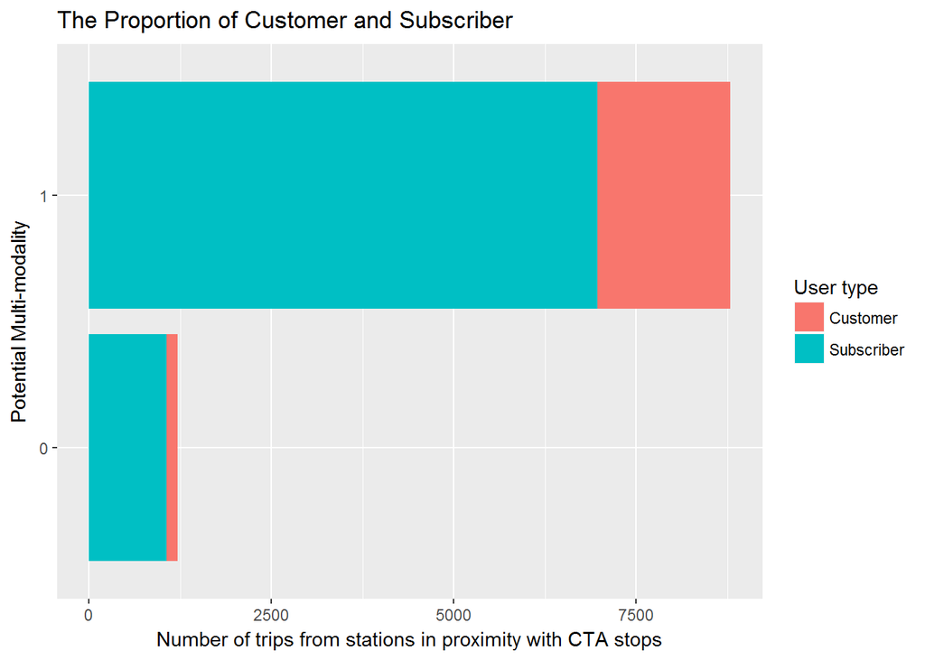

The following interactive table allows for exploring the `fromOutput` dataset.

[interactive chart not shown]

### When Divvy Trips stop at stations in proximity with CTA stops

A simple table below compares between the number of Divvy trips made to stations in proximity with CTA stops that are potentially multi-modal and that are not.

The Number of Divvy Trips that Ends in a Potentially Multi-modal Manner

| Potentially Multi-modal | n |
| --- | --- |
| 0 | 1174 |
| 1 | 8826 |

Similar to what we see above, among trips made to stations in proximity with CTA stop, over 88 percent are potentially multi-modal, i.e., possibly made in connection with public trasit uses.

The following graph compares the proportion of non-members (Customer) and members (Subscriber), for both trips that are potentially multi-modal trip and trips that are not. Again, for trips that stop at stations in proximity with CTA stops, the proportion of Customer trip is much greater for potentially multi-modal trips.

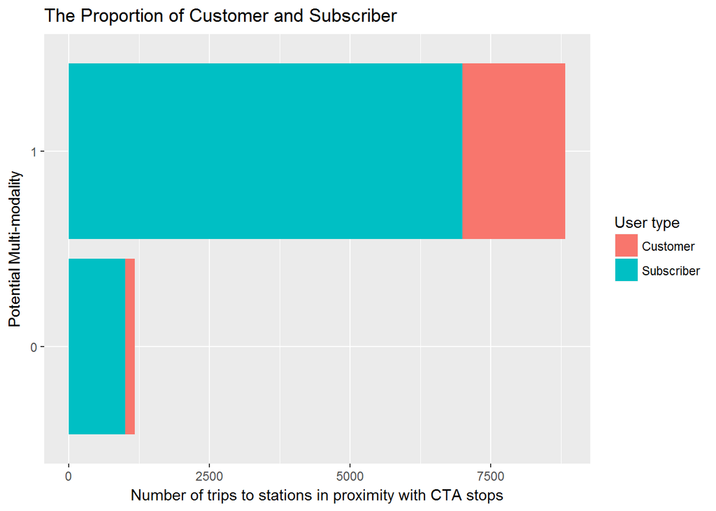

The following interactive table allows for exploring the `toOutput` dataset.

[interactive chart not shown]